# Nutrition-Based Fast Food Clustering (KMeans)

[figure not shown]

# Data Collection

```python
# This Python 3 environment comes with many helpful analytics libraries installed
# It is defined by the kaggle/python Docker image: https://github.com/kaggle/docker-python
# For example, here's several helpful packages to load
import warnings
warnings.filterwarnings("ignore")
import numpy as np # linear algebra
import pandas as pd # data processing, CSV file I/O (e.g. pd.read_csv)
import seaborn as sns
# Input data files are available in the read-only "../input/" directory
# For example, running this (by clicking run or pressing Shift+Enter) will list all files under the input directory

import os
for dirname, _, filenames in os.walk('/kaggle/input'):
    for filename in filenames:
        print(os.path.join(dirname, filename))

# You can write up to 20GB to the current directory (/kaggle/working/) that gets preserved as output when you create a version using "Save & Run All"
# <p style="background-color:#35A29F;font-family:newtimeroman;color:#FFF9ED;font-size:150%;text-align:center;border-radius:10px 10px; padding: 15px">Data Collection </p> # You can also write temporary files to /kaggle/temp/, but they won't be saved outside of the current session
```

```
/kaggle/input/fastfood-nutrition/fastfood.csv
```

# Data Understanding

```python
pd.set_option("display.max_column",None)
df = pd.read_csv("/kaggle/input/fastfood-nutrition/fastfood.csv")
df.head(3)
```

|  | restaurant | item | calories | cal_fat | total_fat | sat_fat | trans_fat | cholesterol | sodium | total_carb | fiber | sugar | protein | vit_a | vit_c | calcium | salad |
| --- | --- | --- | --- | --- | --- | --- | --- | --- | --- | --- | --- | --- | --- | --- | --- | --- | --- |
| 0 | Mcdonalds | Artisan Grilled Chicken Sandwich | 380 | 60 | 7 | 2.0 | 0.0 | 95 | 1110 | 44 | 3.0 | 11 | 37.0 | 4.0 | 20.0 | 20.0 | Other |
| 1 | Mcdonalds | Single Bacon Smokehouse Burger | 840 | 410 | 45 | 17.0 | 1.5 | 130 | 1580 | 62 | 2.0 | 18 | 46.0 | 6.0 | 20.0 | 20.0 | Other |
| 2 | Mcdonalds | Double Bacon Smokehouse Burger | 1130 | 600 | 67 | 27.0 | 3.0 | 220 | 1920 | 63 | 3.0 | 18 | 70.0 | 10.0 | 20.0 | 50.0 | Other |

```python
df.shape
```

```
(515, 17)
```

```python
df.describe()
```

|  | calories | cal_fat | total_fat | sat_fat | trans_fat | cholesterol | sodium | total_carb | fiber | sugar | protein | vit_a | vit_c | calcium |
| --- | --- | --- | --- | --- | --- | --- | --- | --- | --- | --- | --- | --- | --- | --- |
| count | 515.000000 | 515.000000 | 515.000000 | 515.000000 | 515.000000 | 515.000000 | 515.000000 | 515.000000 | 503.000000 | 515.000000 | 514.000000 | 301.000000 | 305.000000 | 305.000000 |
| mean | 530.912621 | 238.813592 | 26.590291 | 8.153398 | 0.465049 | 72.456311 | 1246.737864 | 45.664078 | 4.137177 | 7.262136 | 27.891051 | 18.857143 | 20.170492 | 24.852459 |
| std | 282.436147 | 166.407510 | 18.411876 | 6.418811 | 0.839644 | 63.160406 | 689.954278 | 24.883342 | 3.037460 | 6.761301 | 17.683921 | 31.384330 | 30.592243 | 25.522073 |
| min | 20.000000 | 0.000000 | 0.000000 | 0.000000 | 0.000000 | 0.000000 | 15.000000 | 0.000000 | 0.000000 | 0.000000 | 1.000000 | 0.000000 | 0.000000 | 0.000000 |
| 25% | 330.000000 | 120.000000 | 14.000000 | 4.000000 | 0.000000 | 35.000000 | 800.000000 | 28.500000 | 2.000000 | 3.000000 | 16.000000 | 4.000000 | 4.000000 | 8.000000 |
| 50% | 490.000000 | 210.000000 | 23.000000 | 7.000000 | 0.000000 | 60.000000 | 1110.000000 | 44.000000 | 3.000000 | 6.000000 | 24.500000 | 10.000000 | 10.000000 | 20.000000 |
| 75% | 690.000000 | 310.000000 | 35.000000 | 11.000000 | 1.000000 | 95.000000 | 1550.000000 | 57.000000 | 5.000000 | 9.000000 | 36.000000 | 20.000000 | 30.000000 | 30.000000 |
| max | 2430.000000 | 1270.000000 | 141.000000 | 47.000000 | 8.000000 | 805.000000 | 6080.000000 | 156.000000 | 17.000000 | 87.000000 | 186.000000 | 180.000000 | 400.000000 | 290.000000 |

```python
df.info()
```

```
<class 'pandas.core.frame.DataFrame'>
RangeIndex: 515 entries, 0 to 514
Data columns (total 17 columns):
 #   Column       Non-Null Count  Dtype
---  ------       --------------  -----
 0   restaurant   515 non-null    object
 1   item         515 non-null    object
 2   calories     515 non-null    int64
 3   cal_fat      515 non-null    int64
 4   total_fat    515 non-null    int64
 5   sat_fat      515 non-null    float64
 6   trans_fat    515 non-null    float64
 7   cholesterol  515 non-null    int64
 8   sodium       515 non-null    int64
 9   total_carb   515 non-null    int64
 10  fiber        503 non-null    float64
 11  sugar        515 non-null    int64
 12  protein      514 non-null    float64
 13  vit_a        301 non-null    float64
 14  vit_c        305 non-null    float64
 15  calcium      305 non-null    float64
 16  salad        515 non-null    object
dtypes: float64(7), int64(7), object(3)
memory usage: 68.5+ KB
```

```python
df.isna().sum()
```

```
restaurant       0
item             0
calories         0
cal_fat          0
total_fat        0
sat_fat          0
trans_fat        0
cholesterol      0
sodium           0
total_carb       0
fiber           12
sugar            0
protein          1
vit_a          214
vit_c          210
calcium        210
salad            0
dtype: int64
```

# Data Preprocessing

Data pre-processing is a crucial step in data analysis and machine learning that involves cleaning, transforming, and preparing the raw data to make it suitable for further analysis. It aims to improve the quality and reliability of the data, ensuring that the data is in a format that can be used effectively by algorithms and models.

Data pre-processing involves:

- 1- Data Cleaning
- 2- Data Transformation
- 3- Feature Selection
- 4- Feature Engineering
- 5- Data Normalization

```python
df = df.drop('restaurant', axis=1)
```

```python
df_columns= df.columns
df_columns
```

```
Index(['item', 'calories', 'cal_fat', 'total_fat', 'sat_fat', 'trans_fat',
       'cholesterol', 'sodium', 'total_carb', 'fiber', 'sugar', 'protein',
       'vit_a', 'vit_c', 'calcium', 'salad'],
      dtype='object')
```

```python
df_num_cols = df.select_dtypes(include=np.number).columns.to_list()
df_cat_cols = df.select_dtypes(exclude=np.number).columns.to_list()


df_cat_cols
```

```
['item', 'salad']
```

```python
# dealing outliers for training
# Calculate the 1st and 99th percentile of each column
quantiles = df[df_num_cols].quantile([0.1, 0.90])

# Winsorize each column to cap extreme values at the 1st and 99th percentile
df[df_num_cols] = df[df_num_cols].apply(lambda x: np.clip(x, quantiles.loc[0.1, x.name], quantiles.loc[0.90, x.name]))
```

```python
df.describe()
```

|  | calories | cal_fat | total_fat | sat_fat | trans_fat | cholesterol | sodium | total_carb | fiber | sugar | protein | vit_a | vit_c | calcium |
| --- | --- | --- | --- | --- | --- | --- | --- | --- | --- | --- | --- | --- | --- | --- |
| count | 515.000000 | 515.000000 | 515.000000 | 515.000000 | 515.000000 | 515.000000 | 515.000000 | 515.000000 | 503.000000 | 515.000000 | 514.000000 | 301.000000 | 305.000000 | 305.000000 |
| mean | 512.450485 | 224.814369 | 24.990291 | 7.445631 | 0.370874 | 65.582524 | 1194.368932 | 44.608155 | 3.958250 | 6.625243 | 26.419066 | 13.823920 | 17.904918 | 23.222951 |
| std | 215.247390 | 115.567919 | 12.947736 | 4.203940 | 0.547657 | 35.320248 | 489.242386 | 20.531339 | 2.494665 | 4.091053 | 11.530975 | 12.066437 | 16.842756 | 17.494815 |
| min | 210.000000 | 77.000000 | 8.000000 | 2.000000 | 0.000000 | 20.000000 | 530.000000 | 15.000000 | 1.000000 | 1.000000 | 12.000000 | 0.000000 | 2.000000 | 4.000000 |
| 25% | 330.000000 | 120.000000 | 14.000000 | 4.000000 | 0.000000 | 35.000000 | 800.000000 | 28.500000 | 2.000000 | 3.000000 | 16.000000 | 4.000000 | 4.000000 | 8.000000 |
| 50% | 490.000000 | 210.000000 | 23.000000 | 7.000000 | 0.000000 | 60.000000 | 1110.000000 | 44.000000 | 3.000000 | 6.000000 | 24.500000 | 10.000000 | 10.000000 | 20.000000 |
| 75% | 690.000000 | 310.000000 | 35.000000 | 11.000000 | 1.000000 | 95.000000 | 1550.000000 | 57.000000 | 5.000000 | 9.000000 | 36.000000 | 20.000000 | 30.000000 | 30.000000 |
| max | 886.000000 | 431.200000 | 48.000000 | 15.000000 | 1.500000 | 130.000000 | 2050.000000 | 82.600000 | 9.000000 | 14.000000 | 46.700000 | 40.000000 | 50.000000 | 60.000000 |

# EDA

Exploratory Data Analysis (EDA) is a critical initial step in the data analysis process. It involves examining and summarizing the main characteristics and patterns present in a dataset to gain insights, detect anomalies, and formulate hypotheses for further investigation. EDA is a fundamental practice in data science and helps analysts and data scientists understand the nature of the data they are working with.

# Data Visualization

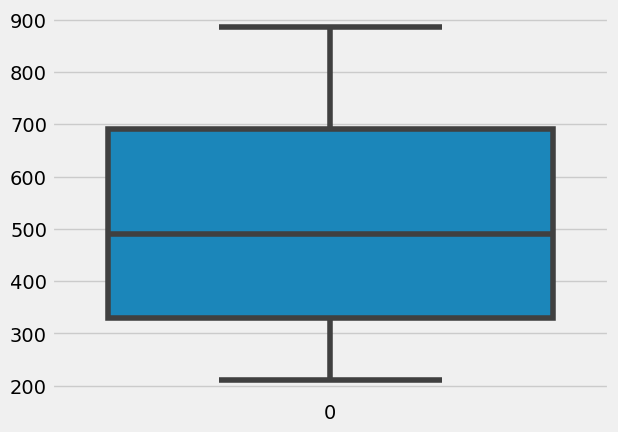

```python
sns.boxplot(df['calories'])
```

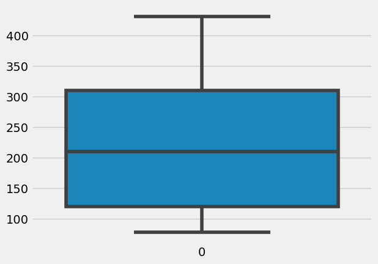

```python
sns.boxplot(df['cal_fat'])
```

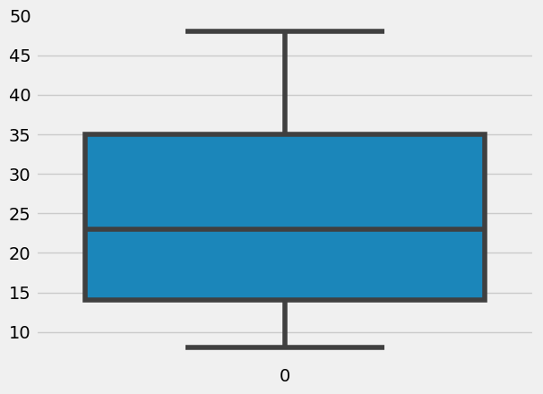

```python
sns.boxplot(df['total_fat'])
```

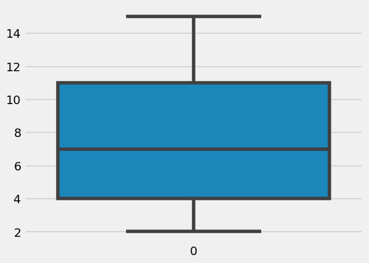

```python
sns.boxplot(df['sat_fat'])
```

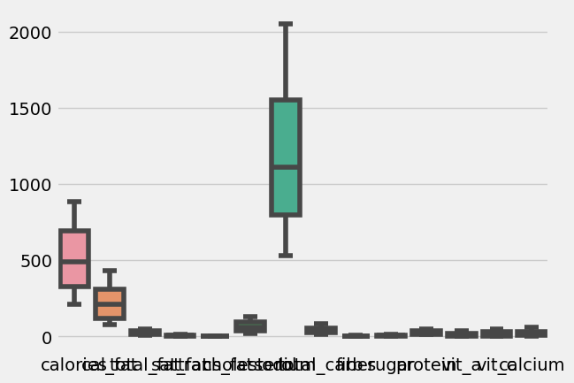

```python
sns.boxplot(df.drop('item',axis=1))
```

# Filling missing values

```python
df['fiber'] = df['fiber'].fillna(value= 3.958250)
```

```python
df['fiber'].isna().sum()
```

```
0
```

```python
df['vit_a'] = df['vit_a'].fillna(value= 13.82)
```

```python
df['vit_c'] = df['vit_c'].fillna(value= 17.904918)
```

```python
df['calcium'] = df['calcium'].fillna(value= 23.222951)
```

```python
df['protein'] = df['protein'].fillna(value= 26.419066)
```

```python
df.isna().sum()
```

```
item           0
calories       0
cal_fat        0
total_fat      0
sat_fat        0
trans_fat      0
cholesterol    0
sodium         0
total_carb     0
fiber          0
sugar          0
protein        0
vit_a          0
vit_c          0
calcium        0
salad          0
dtype: int64
```

```python
df = df.drop('salad', axis= 1)
```

```python
df[df_num_cols].skew()
```

```
calories       0.280375
cal_fat        0.429794
total_fat      0.424050
sat_fat        0.460868
trans_fat      1.051755
cholesterol    0.476282
sodium         0.365122
total_carb     0.341450
fiber          0.788081
sugar          0.449488
protein        0.374091
vit_a          1.244092
vit_c          1.069226
calcium        1.091486
dtype: float64
```

```python
df.info()
```

```
<class 'pandas.core.frame.DataFrame'>
RangeIndex: 515 entries, 0 to 514
Data columns (total 15 columns):
 #   Column       Non-Null Count  Dtype
---  ------       --------------  -----
 0   item         515 non-null    object
 1   calories     515 non-null    int64
 2   cal_fat      515 non-null    float64
 3   total_fat    515 non-null    int64
 4   sat_fat      515 non-null    float64
 5   trans_fat    515 non-null    float64
 6   cholesterol  515 non-null    int64
 7   sodium       515 non-null    int64
 8   total_carb   515 non-null    float64
 9   fiber        515 non-null    float64
 10  sugar        515 non-null    int64
 11  protein      515 non-null    float64
 12  vit_a        515 non-null    float64
 13  vit_c        515 non-null    float64
 14  calcium      515 non-null    float64
dtypes: float64(9), int64(5), object(1)
memory usage: 60.5+ KB
```

```python
df1 = df[df_num_cols]
df1.columns
```

```
Index(['calories', 'cal_fat', 'total_fat', 'sat_fat', 'trans_fat',
       'cholesterol', 'sodium', 'total_carb', 'fiber', 'sugar', 'protein',
       'vit_a', 'vit_c', 'calcium'],
      dtype='object')
```

# Finding K (using Elbow Method)

The elbow method is a simple and intuitive technique used in data analysis and machine learning to determine the optimal number of clusters for a given dataset during a clustering task. Clustering is the process of grouping similar data points together based on their similarities.

- Step 1: Choosing the number of clusters
- Step 2: Applying K-Means clustering
- Step 3: Evaluating within-cluster variance
- Step 4: Plotting the results
- Step 5: Identifying the "elbow point"
- Step 6: Selecting the optimal number of clusters

```python
from sklearn.cluster import KMeans
import matplotlib.pyplot as plt
import matplotlib.style as style
```

```
Inertia: 154965586.06458056
Inertia: 48959325.362029254
Inertia: 27335291.235612053
Inertia: 18510969.09074006
```

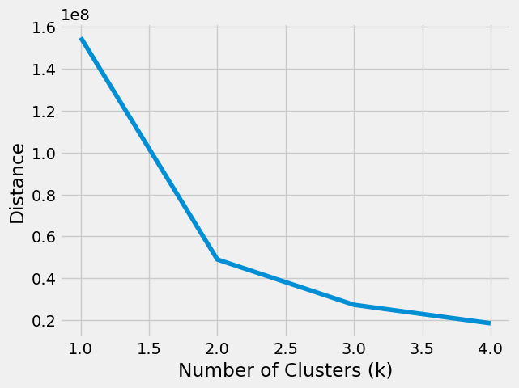

```python
range_n_clusters = [1, 2, 3, 4]
avg_distance=[]
for n_clusters in range_n_clusters:
    clusterer = KMeans(n_clusters=n_clusters, random_state=42).fit(df[df_num_cols])
    inertia = clusterer.inertia_
    print("Inertia:", inertia)
    labels = clusterer.fit_predict(df[df_num_cols])
    avg_distance.append(clusterer.inertia_)

style.use("fivethirtyeight")
plt.plot(range_n_clusters, avg_distance)
plt.xlabel("Number of Clusters (k)")
plt.ylabel("Distance")
plt.show()
```

```python
clusterer
```

```
KMeans(n_clusters=4, random_state=42)
```

```python
labels
```

```
array([2, 3, 1, 1, 1, 2, 0, 2, 2, 3, 0, 2, 2, 3, 0, 0, 3, 1, 1, 0, 2, 2,
       2, 3, 3, 2, 2, 2, 2, 3, 3, 3, 1, 1, 2, 3, 1, 1, 1, 1, 0, 0, 2, 1,
       1, 1, 1, 1, 0, 0, 2, 0, 2, 2, 0, 2, 2, 2, 0, 0, 0, 0, 2, 3, 3, 0,
       0, 2, 3, 1, 2, 3, 0, 0, 0, 0, 3, 2, 2, 3, 1, 2, 1, 1, 3, 2, 0, 0,
       0, 2, 3, 3, 2, 2, 2, 3, 3, 3, 1, 3, 1, 3, 1, 3, 3, 3, 3, 3, 2, 2,
       0, 0, 3, 3, 1, 1, 2, 1, 2, 3, 1, 1, 1, 0, 2, 2, 3, 1, 2, 1, 2, 2,
       2, 3, 0, 1, 2, 2, 2, 3, 1, 3, 1, 1, 1, 1, 1, 3, 1, 2, 3, 1, 3, 3,
       1, 1, 1, 2, 1, 2, 3, 0, 2, 3, 1, 3, 1, 3, 1, 1, 1, 3, 3, 2, 1, 1,
       1, 3, 1, 2, 0, 2, 0, 0, 2, 0, 0, 0, 2, 0, 0, 3, 1, 3, 2, 0, 1, 1,
       1, 0, 2, 2, 0, 1, 2, 1, 0, 2, 3, 3, 0, 1, 3, 1, 1, 3, 3, 3, 2, 3,
       0, 0, 3, 1, 3, 1, 3, 1, 2, 3, 0, 2, 0, 0, 1, 0, 3, 2, 2, 1, 0, 0,
       0, 3, 2, 3, 1, 2, 2, 2, 2, 2, 2, 3, 2, 2, 1, 0, 3, 2, 3, 1, 1, 3,
       3, 2, 2, 2, 3, 1, 1, 2, 2, 2, 2, 2, 2, 0, 0, 2, 1, 3, 0, 2, 2, 3,
       2, 0, 3, 2, 1, 2, 2, 3, 3, 0, 3, 2, 3, 0, 2, 0, 0, 3, 0, 3, 0, 3,
       3, 1, 3, 1, 0, 0, 3, 2, 1, 3, 1, 2, 1, 2, 1, 2, 1, 1, 1, 3, 1, 3,
       1, 2, 1, 0, 3, 0, 0, 3, 0, 2, 3, 1, 2, 1, 2, 1, 2, 3, 0, 3, 2, 1,
       0, 3, 2, 1, 0, 0, 3, 0, 3, 3, 1, 0, 0, 0, 0, 3, 2, 0, 2, 2, 0, 2,
       2, 0, 2, 0, 0, 2, 2, 0, 0, 0, 2, 0, 0, 2, 0, 0, 0, 0, 0, 1, 1, 1,
       3, 2, 3, 3, 3, 3, 2, 2, 3, 2, 2, 2, 2, 2, 1, 1, 1, 2, 2, 3, 3, 3,
       2, 3, 3, 3, 2, 1, 1, 1, 1, 1, 1, 2, 1, 1, 1, 0, 0, 0, 0, 0, 0, 0,
       0, 0, 0, 0, 0, 0, 0, 0, 0, 0, 0, 0, 0, 0, 0, 0, 0, 2, 2, 2, 3, 2,
       2, 2, 0, 0, 0, 0, 2, 2, 2, 2, 2, 0, 0, 0, 3, 3, 0, 0, 0, 2, 0, 2,
       2, 3, 3, 3, 2, 0, 3, 3, 2, 0, 3, 2, 0, 3, 2, 2, 0, 2, 2, 2, 0, 2,
       0, 2, 3, 3, 1, 3, 3, 3, 3], dtype=int32)
```

```python
u_labels = np.unique(labels)
u_labels
```

```
array([0, 1, 2, 3], dtype=int32)
```

```python
# #plotting the results:
# for i in u_labels:
#     print("hello")
#     plt.scatter(df[labels == i , 0] , df[labels == i , 1] , labels = i)
# plt.legend()
# plt.show()
```

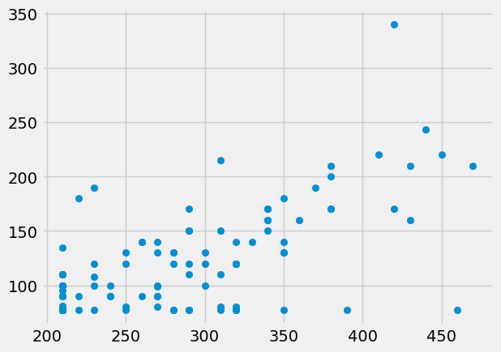

```python
filtered_label0 = df1[labels == 0]
filtered_label0

# Plotting the results
plt.scatter(filtered_label0.iloc[:, 0], filtered_label0.iloc[:, 1])
plt.show()
```

[figure not shown]

```python
import matplotlib.pyplot as plt
import numpy as np

# Set the figure size
plt.figure(figsize=(12, 6))

# Convert boolean array to list of indices
for i in u_labels:
    indices = np.where(labels == i)[0]

    # Plotting the results
    plt.scatter(df.iloc[indices, 0], df.iloc[indices, 1], label=f"Cluster {i}")

plt.legend()
plt.show()
```

# Feature Engineering

Feature engineering is a critical step in the data preprocessing and machine learning pipeline, where domain knowledge and creativity are used to transform raw data into informative and meaningful features that enhance the performance of machine learning models. Unnecessay items are dropped in this step.

```python
df.head()
```

|  | item | calories | cal_fat | total_fat | sat_fat | trans_fat | cholesterol | sodium | total_carb | fiber | sugar | protein | vit_a | vit_c | calcium |
| --- | --- | --- | --- | --- | --- | --- | --- | --- | --- | --- | --- | --- | --- | --- | --- |
| 0 | Artisan Grilled Chicken Sandwich | 380 | 77.0 | 8 | 2.0 | 0.0 | 95 | 1110 | 44.0 | 3.0 | 11 | 37.0 | 4.0 | 20.0 | 20.0 |
| 1 | Single Bacon Smokehouse Burger | 840 | 410.0 | 45 | 15.0 | 1.5 | 130 | 1580 | 62.0 | 2.0 | 14 | 46.0 | 6.0 | 20.0 | 20.0 |
| 2 | Double Bacon Smokehouse Burger | 886 | 431.2 | 48 | 15.0 | 1.5 | 130 | 1920 | 63.0 | 3.0 | 14 | 46.7 | 10.0 | 20.0 | 50.0 |
| 3 | Grilled Bacon Smokehouse Chicken Sandwich | 750 | 280.0 | 31 | 10.0 | 0.5 | 130 | 1940 | 62.0 | 2.0 | 14 | 46.7 | 6.0 | 25.0 | 20.0 |
| 4 | Crispy Bacon Smokehouse Chicken Sandwich | 886 | 410.0 | 45 | 12.0 | 0.5 | 120 | 1980 | 81.0 | 4.0 | 14 | 46.0 | 6.0 | 20.0 | 20.0 |

```python
df.shape
```

```
(515, 15)
```

```python
df = df.drop(['cal_fat','sat_fat','trans_fat'],axis=1)
```

```python
df
```

|  | item | calories | total_fat | cholesterol | sodium | total_carb | fiber | sugar | protein | vit_a | vit_c | calcium |
| --- | --- | --- | --- | --- | --- | --- | --- | --- | --- | --- | --- | --- |
| 0 | Artisan Grilled Chicken Sandwich | 380 | 8 | 95 | 1110 | 44.0 | 3.0 | 11 | 37.0 | 4.00 | 20.000000 | 20.000000 |
| 1 | Single Bacon Smokehouse Burger | 840 | 45 | 130 | 1580 | 62.0 | 2.0 | 14 | 46.0 | 6.00 | 20.000000 | 20.000000 |
| 2 | Double Bacon Smokehouse Burger | 886 | 48 | 130 | 1920 | 63.0 | 3.0 | 14 | 46.7 | 10.00 | 20.000000 | 50.000000 |
| 3 | Grilled Bacon Smokehouse Chicken Sandwich | 750 | 31 | 130 | 1940 | 62.0 | 2.0 | 14 | 46.7 | 6.00 | 25.000000 | 20.000000 |
| 4 | Crispy Bacon Smokehouse Chicken Sandwich | 886 | 45 | 120 | 1980 | 81.0 | 4.0 | 14 | 46.0 | 6.00 | 20.000000 | 20.000000 |
| ... | ... | ... | ... | ... | ... | ... | ... | ... | ... | ... | ... | ... |
| 510 | Spicy Triple Double Crunchwrap | 780 | 38 | 50 | 1850 | 82.6 | 9.0 | 8 | 23.0 | 20.00 | 10.000000 | 25.000000 |
| 511 | Express Taco Salad w/ Chips | 580 | 29 | 60 | 1270 | 59.0 | 8.0 | 7 | 23.0 | 13.82 | 17.904918 | 23.222951 |
| 512 | Fiesta Taco Salad-Beef | 780 | 42 | 60 | 1340 | 74.0 | 9.0 | 7 | 26.0 | 13.82 | 17.904918 | 23.222951 |
| 513 | Fiesta Taco Salad-Chicken | 720 | 35 | 70 | 1260 | 70.0 | 8.0 | 8 | 32.0 | 13.82 | 17.904918 | 23.222951 |
| 514 | Fiesta Taco Salad-Steak | 720 | 36 | 55 | 1340 | 70.0 | 8.0 | 8 | 28.0 | 13.82 | 17.904918 | 23.222951 |

515 rows × 12 columns

```python
df.shape
```

```
(515, 12)
```

```python
df.info()
```

```
<class 'pandas.core.frame.DataFrame'>
RangeIndex: 515 entries, 0 to 514
Data columns (total 12 columns):
 #   Column       Non-Null Count  Dtype
---  ------       --------------  -----
 0   item         515 non-null    object
 1   calories     515 non-null    int64
 2   total_fat    515 non-null    int64
 3   cholesterol  515 non-null    int64
 4   sodium       515 non-null    int64
 5   total_carb   515 non-null    float64
 6   fiber        515 non-null    float64
 7   sugar        515 non-null    int64
 8   protein      515 non-null    float64
 9   vit_a        515 non-null    float64
 10  vit_c        515 non-null    float64
 11  calcium      515 non-null    float64
dtypes: float64(6), int64(5), object(1)
memory usage: 48.4+ KB
```

# Adding labels to the specific item

After dividing the data into 4 clusters, each cluster is assigned with a specific label depending upon the ratio of nutrients in that cluster.

```python
kmeans = KMeans(n_clusters=5)
```

```python
labels = clusterer.labels_
labels[:10]
```

```
array([2, 3, 1, 1, 1, 2, 0, 2, 2, 3], dtype=int32)
```

```python
df['labels'] = labels
df.sample(3)
```

|  | item | calories | total_fat | cholesterol | sodium | total_carb | fiber | sugar | protein | vit_a | vit_c | calcium | labels |
| --- | --- | --- | --- | --- | --- | --- | --- | --- | --- | --- | --- | --- | --- |
| 19 | McChicken | 350 | 15 | 40 | 600 | 40.0 | 2.0 | 5 | 15.0 | 2.00 | 2.000000 | 4.000000 | 0 |
| 185 | Roast Beef 'n Cheese Slider | 240 | 11 | 30 | 670 | 21.0 | 1.0 | 1 | 14.0 | 13.82 | 17.904918 | 23.222951 | 0 |
| 178 | Ultimate BLT | 886 | 48 | 85 | 2050 | 80.0 | 6.0 | 14 | 43.0 | 13.82 | 17.904918 | 23.222951 | 1 |

```python
df['labels'].value_counts()
```

```
2    150
0    133
3    123
1    109
Name: labels, dtype: int64
```

```python
positive_ntr = ['protein','calcium','total_carb','vit_a','vit_c','fiber']
negative_ntr = ['sugar','calories','total_fat','sodium','cholesterol']
```

```python
df.describe()
```

|  | calories | total_fat | cholesterol | sodium | total_carb | fiber | sugar | protein | vit_a | vit_c | calcium | labels |
| --- | --- | --- | --- | --- | --- | --- | --- | --- | --- | --- | --- | --- |
| count | 515.000000 | 515.000000 | 515.000000 | 515.000000 | 515.000000 | 515.000000 | 515.000000 | 515.000000 | 515.000000 | 515.000000 | 515.000000 | 515.000000 |
| mean | 512.450485 | 24.990291 | 65.582524 | 1194.368932 | 44.608155 | 3.958250 | 6.625243 | 26.419066 | 13.822291 | 17.904918 | 23.222951 | 1.510680 |
| std | 215.247390 | 12.947736 | 35.320248 | 489.242386 | 20.531339 | 2.465372 | 4.091053 | 11.519752 | 9.218454 | 12.952941 | 13.454408 | 1.116459 |
| min | 210.000000 | 8.000000 | 20.000000 | 530.000000 | 15.000000 | 1.000000 | 1.000000 | 12.000000 | 0.000000 | 2.000000 | 4.000000 | 0.000000 |
| 25% | 330.000000 | 14.000000 | 35.000000 | 800.000000 | 28.500000 | 2.000000 | 3.000000 | 16.000000 | 10.000000 | 8.000000 | 15.000000 | 0.000000 |
| 50% | 490.000000 | 23.000000 | 60.000000 | 1110.000000 | 44.000000 | 3.000000 | 6.000000 | 25.000000 | 13.820000 | 17.904918 | 23.222951 | 2.000000 |
| 75% | 690.000000 | 35.000000 | 95.000000 | 1550.000000 | 57.000000 | 5.000000 | 9.000000 | 36.000000 | 15.000000 | 17.904918 | 25.000000 | 2.000000 |
| max | 886.000000 | 48.000000 | 130.000000 | 2050.000000 | 82.600000 | 9.000000 | 14.000000 | 46.700000 | 40.000000 | 50.000000 | 60.000000 | 3.000000 |

```python
label_0 = df[df['labels']==0]
label_1 = df[df['labels']==1]
label_2 = df[df['labels']==2]
label_3 = df[df['labels']==3]

print("label 0",len(label_0))
print("label 1",len(label_1))
print("label 2",len(label_2))
print("label 3",len(label_3))
```

```
label 0 133
label 1 109
label 2 150
label 3 123
```

```python
nutritions = list(label_0.describe().columns)
label_0_nutri_avg = label_0.describe().mean().values
label_1_nutri_avg = label_1.describe().mean().values
label_2_nutri_avg = label_2.describe().mean().values
label_3_nutri_avg = label_3.describe().mean().values


print("label_0_nutri_avg",label_0_nutri_avg)
print("label_1_nutri_avg",label_1_nutri_avg)
print("label_2_nutri_avg",label_2_nutri_avg)
print("label_3_nutri_avg",label_3_nutri_avg)
```

```
label_0_nutri_avg [241.86077902  28.70584882  51.17114789 505.2003118   42.15806243
  19.49234778  20.73188573  30.84158713  29.22916863  33.83442538
  34.87012949  16.625     ]
label_1_nutri_avg [ 557.40481948   41.645938     87.23886581 1466.82186168   61.6598988
   17.71998633   20.84358769   42.34354286   26.0016794    30.226694
   37.42531214   14.375     ]
label_2_nutri_avg [366.59988711  37.37736708  67.93531691 791.55266134  52.16219638
  21.97013957  23.80845003  38.1084021   31.50454506  34.19421685
  38.29545203  20.25      ]
label_3_nutri_avg [ 505.94660858   39.50009219   76.6496241  1070.94995278   56.49107798
   19.01237692   21.49538442   39.75951306   26.9938335    30.57974892
   38.16927379   17.625     ]
```

# Plotting of Each Cluster Label

Plotting each cluster label involves visualizing the data points in a scatter plot or other suitable visual representation, where each data point is colored or marked according to the cluster label assigned by the clustering algorithm. This visualization allows us to observe the distribution and separation of data points belonging to different clusters, providing insights into the effectiveness of the clustering process

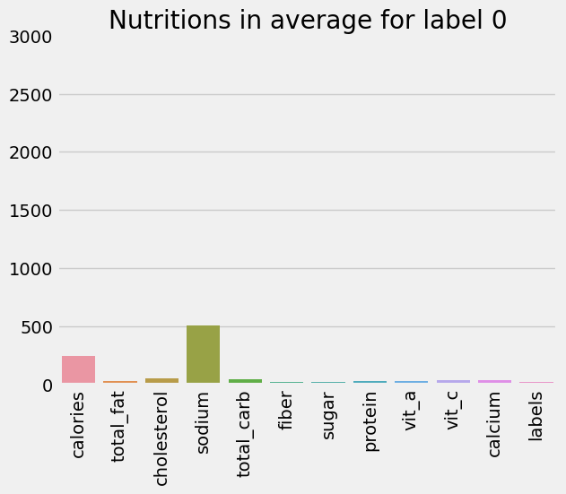

```python
# label 0
sns.barplot(x=nutritions,y=label_0_nutri_avg)
plt.title("Nutritions in average for label 0")
plt.xticks(rotation=90)
plt.ylim([0,3000])
plt.show()
```

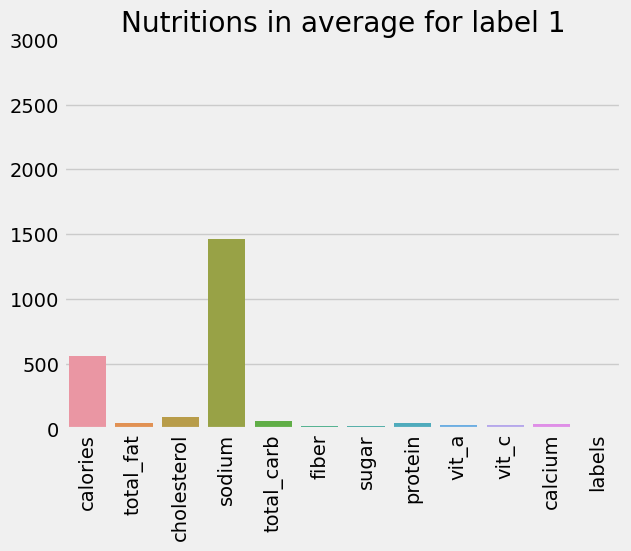

```python
# label 0
sns.barplot(x=nutritions,y=label_1_nutri_avg)
plt.title("Nutritions in average for label 1")
plt.xticks(rotation=90)
plt.ylim([0,3000])
plt.show()
```

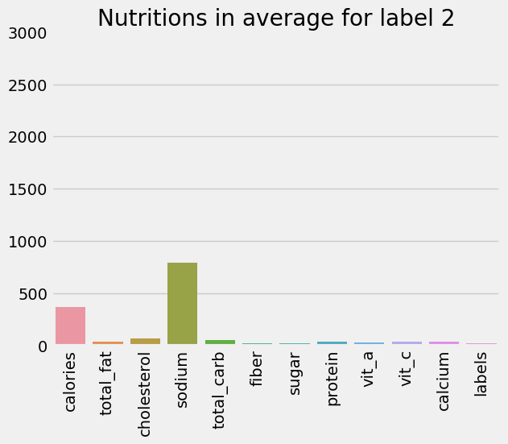

```python
# label 0
sns.barplot(x=nutritions,y=label_2_nutri_avg)
plt.title("Nutritions in average for label 2")
plt.xticks(rotation=90)
plt.ylim([0,3000])
plt.show()
```

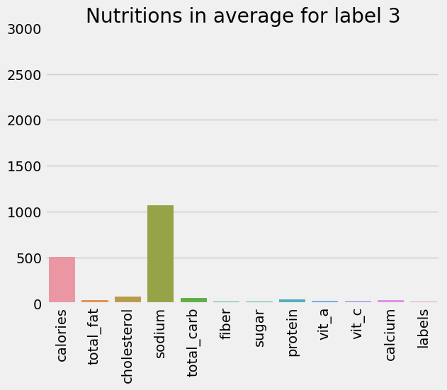

```python
# label 0
sns.barplot(x=nutritions,y=label_3_nutri_avg)
plt.title("Nutritions in average for label 3")
plt.xticks(rotation=90)
plt.ylim([0,3000])
plt.show()
```

# Analysis on the basis of Positive and Negative Nutrients

Analyzing positive and negative nutrients in a food product or diet is essential for understanding its nutritional composition and potential health implications. This analysis empowers individuals to make healthier dietary choices, ensuring that they receive the necessary nutrients while minimizing the intake of unhealthy components.

```python
positive_ntr = ['protein','calcium','total_carb','vit_a','vit_c','fiber']
negative_ntr = ['sugar','calories','total_fat','sodium','cholesterol']
```

```python
def zipper(lis1,lis2):
    temp = {}
    for v1,v2 in zip(lis1,lis2):
        temp[v1] = v2
    return temp

label_0_dic = zipper(nutritions,label_0_nutri_avg)
label_1_dic = zipper(nutritions,label_1_nutri_avg)
label_2_dic = zipper(nutritions,label_2_nutri_avg)
label_3_dic = zipper(nutritions,label_3_nutri_avg)

print("label_0_zipped",label_0_dic)
print("\n\nlabel_1_zipped",label_1_dic)
print("\n\nlabel_2_zipped",label_2_dic)
print("\n\nlabel_3_zipped",label_3_dic)
```

```
label_0_zipped {'calories': 241.86077901840707, 'total_fat': 28.705848819643055, 'cholesterol': 51.17114789416934, 'sodium': 505.20031180163227, 'total_carb': 42.158062428326694, 'fiber': 19.49234777773501, 'sugar': 20.731885729950672, 'protein': 30.841587129985285, 'vit_a': 29.22916863179173, 'vit_…


label_1_zipped {'calories': 557.4048194785663, 'total_fat': 41.64593800434909, 'cholesterol': 87.23886581452007, 'sodium': 1466.8218616827107, 'total_carb': 61.65989879912388, 'fiber': 17.719986332144618, 'sugar': 20.843587693340915, 'protein': 42.343542863206714, 'vit_a': 26.00167939529836, 'vit_c'…


label_2_zipped {'calories': 366.5998871145427, 'total_fat': 37.37736707874442, 'cholesterol': 67.9353169056472, 'sodium': 791.5526613385753, 'total_carb': 52.1621963807031, 'fiber': 21.970139569957148, 'sugar': 23.808450025059013, 'protein': 38.108402100315516, 'vit_a': 31.504545059567292, 'vit_c': …


label_3_zipped {'calories': 505.946608584412, 'total_fat': 39.50009219425293, 'cholesterol': 76.64962410049392, 'sodium': 1070.9499527790385, 'total_carb': 56.49107797608117, 'fiber': 19.012376923820963, 'sugar': 21.495384420026735, 'protein': 39.75951306285044, 'vit_a': 26.993833499131018, 'vit_c':…
```

```python
pn_avg_label_0 = {}
pn_avg_label_1 = {}
pn_avg_label_2 = {}
pn_avg_label_3 = {}
for i in range(3):
    lis1 = []
    lis2 = []
    lis3 = []
    lis4 = []
    for pos_val in positive_ntr:
        lis1.append(label_0_dic[pos_val])
        lis2.append(label_1_dic[pos_val])
        lis3.append(label_2_dic[pos_val])
        lis4.append(label_3_dic[pos_val])
    pn_avg_label_0['pos'] = sum(lis1)/len(lis1)
    pn_avg_label_1['pos'] = sum(lis2)/len(lis2)
    pn_avg_label_2['pos'] = sum(lis3)/len(lis3)
    pn_avg_label_3['pos'] = sum(lis4)/len(lis4)


for i in range(3):
    lis1 = []
    lis2 = []
    lis3 = []
    lis4 = []
    for pos_val in negative_ntr:
        lis1.append(label_0_dic[pos_val])
        lis2.append(label_1_dic[pos_val])
        lis3.append(label_2_dic[pos_val])
        lis4.append(label_3_dic[pos_val])
    pn_avg_label_0['neg'] = sum(lis1)/len(lis1)
    pn_avg_label_1['neg'] = sum(lis2)/len(lis2)
    pn_avg_label_2['neg'] = sum(lis3)/len(lis3)
    pn_avg_label_3['neg'] = sum(lis4)/len(lis4)
```

```python
pos = [pn_avg_label_0['pos'],pn_avg_label_1['pos'],pn_avg_label_2['pos'],pn_avg_label_3['pos']]
neg = [pn_avg_label_0['neg'],pn_avg_label_1['neg'],pn_avg_label_2['neg'],pn_avg_label_3['neg']]
```

```python
pos
```

```
[31.737620138354114, 35.896185588134664, 36.03915866466636, 35.167637362139054]
```

```python
neg
```

```
[169.53399465276047, 434.7910145346974, 257.4547364925137, 342.9083324156448]
```

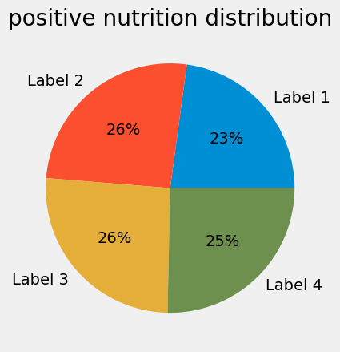

```python
# palette_color = sns.color_palette('bright')
explode = [0,0.1,0,0]
labels = ["Label 1", "Label 2", "Label 3", "Label 4"]
plt.pie(pos, labels=labels,  autopct='%.0f%%')
plt.title("positive nutrition distribution")
plt.show()
```

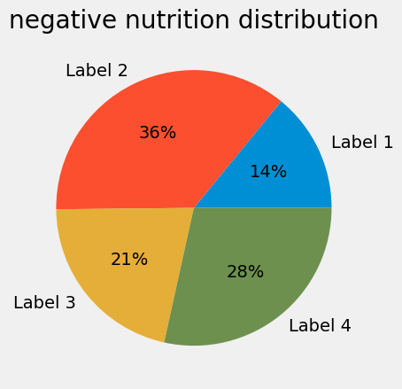

```python
# palette_color = sns.color_palette('bright')
explode = [0,0.1,0,0]
labels = ["Label 1", "Label 2", "Label 3", "Label 4"]
plt.pie(neg, labels=labels,  autopct='%.0f%%')
plt.title("negative nutrition distribution")
plt.show()
```

```python
# label_name = (positive,negative)
label_0_pn = (23,14)
label_1_pn = (26,36)
label_2_pn = (26,21)
label_3_pn = (25,28)
labels_pos_neg = [label_0_pn,label_1_pn,label_2_pn,label_3_pn]
```

```python
labels_pos_neg
```

```
[(23, 14), (26, 36), (26, 21), (25, 28)]
```

```python
healthy_level = [pos-neg for pos,neg in labels_pos_neg]
healthy_level
```

```
[9, -10, 5, -3]
```

```python
# label 0: Healthiest
# label 1: Unhealthy
# label 2: Moderate Healthy
# label 3: Dense Nutrient
```

```python
cluster_labels = {
    0: "Healthy",
    1: "Non-healthy",
    2: "Moderately healthy",
    3: "Nutrient-dense"
}

# # Iterate over the cluster labels and sizes
# for label, size in cluster_sizes.items():
#     cluster_name = cluster_labels.get(label, "Unknown")
#     print("Cluster {}: {} (Size: {})".format(label, cluster_name, size))
```

```python
label_0['item'].unique()
```

```
array(['Cheeseburger', 'Filet-O-Fish®', 'Hamburger', 'Lobster Roll',
       'McChicken', '4 Piece Chicken McNuggets',
       '6 Piece Chicken McNuggets', 'Premium Asian Salad w/o Chicken',
       'Premium Asian Salad w/ Grilled Chicken',
       'Premium Bacon Ranch Salad w/o Chicken',
       'Premium Southwest Salad w/o Chicken',
       'Chargrilled Chicken Sandwich', 'Chick-n-Slider',
       '1 Piece Chick-n-Strips', '2 Piece Chick-n-Strips',
       '4 piece Chicken Nuggets', '6 piece Chicken Nuggets',
       '4 Piece Grilled Chicken Nuggets',
       '6 Piece Grilled Chicken Nuggets',
       '8 piece Grilled Chicken Nuggets',
       '12 Piece Grilled Chicken Nuggets', 'Jr. Burger',
       'Jr. Chili Cheeseburger', 'Jr. Deluxe Burger',
       'Chicken Strip Sandwich', '3 Piece Crispy Chicken Tender Dinner',
       '3 Piece Super Crunch Chicken Strips', 'Corn Dog',
       '2 piece Prime-Cut Chicken Tenders',
       "Chicken Tender 'n Cheese Slider", "Ham 'n Cheese Slider",
       "Jalapeno Roast Beef 'n Cheese Slider",
       "Roast Beef 'n Cheese Slider", "Turkey 'n Cheese Slider",
       'Chopped Side Salad', 'Greek Gyro Salad',
       'Roast Turkey Farmhouse Salad', 'Bacon Cheeseburger Deluxe',
       'Double Hamburger', 'Rodeo Burger', 'WHOPPER JR. w/o Cheese',
       'WHOPPER JR. w/ Cheese',
       'Garden Grilled Chicken Salad w/ Grilled Chicken, no dressing',
       'Side Caesar Salad with dressing',
       'Side Garden Salad and Avocado Ranch Dressing',
       'BBQ Bacon Crispy Chicken Sandwich', 'Chicken Fries',
       '4 Piece Chicken Nuggets', '6 Piece Chicken Nuggets',
       '4 Piece Spicy Chicken Nuggets', 'Barbecue Pork Sandwich',
       'Breaded Mushrooms', 'Deluxe Hamburger',
       'Crispy Chicken Garden Greens Salad',
       'Grilled Chicken Garden Greens Salad', 'Grilled Chicken Wrap',
       'Side Salad', '6" B.L.T.', '6" BBQ Rib Sandwich',
       'Kids Mini Sub Black Forest Ham', '6" Black Forest Ham',
       '6" Oven Roasted Chicken', 'Kids Mini Sub Roast Beef',
       '6" Roast Beef', '6" Rotisserie Style Chicken',
       '6" Subway Seafood Sensation', '6" Tuna',
       'Kids Mini Sub Turkey Breast', '6" Turkey Breast',
       '6" Turkey Breast & Ham', 'Kids Mini Sub Veggie Delite',
```

[output cut: 16 more lines]

```
       'Fiery Doritos® Locos Taco Supreme', 'Grilled Steak Soft Taco',
       'Nacho Cheese Doritos® Double Decker® Taco',
       'Nacho Cheese Doritos® Locos Tacos',
       'Nacho Cheese Doritos® Locos Tacos Supreme',
       'Soft Taco Supreme® – Beef', 'Soft Taco-Beef',
       'Spicy Potato Soft Taco', 'Chalupa Supreme® - Chicken',
       'Chalupa Supreme® - Steak', 'Chalupa Supreme®–Beef',
       'Fresco Chicken Soft Taco', 'Fresco Crunchy Taco',
       'Fresco Grilled Steak Soft Taco', 'Fresco Soft Taco',
       'Gordita Supreme® – Beef', 'Gordita Supreme® - Chicken',
       'Gordita Supreme® - Steak', 'Nachos Supreme',
       'Triple Layer Nachos', 'Triple Melt Nachos',
       'Beefy Mini Quesadilla', 'Cheese Roll-Up',
       'Chipotle Crispy Chicken Griller', 'Double Tostada', 'MexiMelt®',
       'Shredded Chicken Mini Quesadilla', 'Spicy Tostada'], dtype=object)
```

```python
label_1['item'].unique()
```

```
array(['Double Bacon Smokehouse Burger',
       'Grilled Bacon Smokehouse Chicken Sandwich',
       'Crispy Bacon Smokehouse Chicken Sandwich',
       'Grilled Maple Bacon Dijon Chicken Sandwich',
       'Crispy Maple Bacon Dijon Chicken Sandwich',
       'Grilled Sweet BBQ Bacon Chicken Sandwich',
       'Crispy Sweet BBQ Bacon Chicken Sandwich',
       '6 piece Buttermilk Crispy Chicken Tenders',
       '10 piece Buttermilk Crispy Chicken Tenders',
       '12 piece Buttermilk Crispy Chicken Tenders',
       '20 piece Buttermilk Crispy Chicken Tenders',
       '20 Piece Chicken McNuggets', '40 piece Chicken McNuggets',
       "4 piece Sweet N' Spicy Honey BBQ Glazed Tenders",
       "6 piece Sweet N' Spicy Honey BBQ Glazed Tenders",
       "10 piece Sweet N' Spicy Honey BBQ Glazed Tenders",
       '30 piece Chicken Nuggets', 'Spicy Deluxe',
       'Chicken Enchiladas Meal Kit', 'Chicken Parmesan Meal Kit',
       'Super Sonic Bacon Double Cheeseburger (w/mayo)',
       'Super Sonic Double Cheeseburger W/ Ketchup',
       'Super Sonic Jalapeno Double Cheeseburger',
       'Buffalo Dunked Ultimate Chicken Sandwich',
       'Garlic Parmesan Dunked Ultimate Chicken Sandwich',
       'Large Jumbo Popcorn Chicken',
       '3 Piece Super Crunch Chicken Strip Dinner',
       '4 Piece Super Crunch Chicken Strip Dinner',
       '5 Piece Super Crunch Chicken Strip Dinner',
       'Ultimate Chicken Club', 'All Beef Chicago Dog – 6"',
       'Footlong Quarter Pound Coney', "Beef 'n Cheddar Mid",
       'Bourbon BBQ Chicken Sandwich', 'Bourbon BBQ Steak Sandwich',
       'Buttermilk Buffalo Chicken Sandwich',
       'Buttermilk Chicken Bacon & Swiss',
       'Buttermilk Chicken Cordon Bleu Sandwich',
       'Classic French Dip & Swiss/Au Jus', 'Fire-Roasted Philly Steak',
       "Half Pound Beef 'n Cheddar Sandwich",
       'Half Pound French Dip & Swiss', 'Half Pound Roast Beef Sandwich',
       'Loaded Italian Sandwich', 'Reuben Sandwich',
       'Roast Turkey & Swiss Sandwich',
       'Roast Turkey, Ranch & Bacon Sandwich',
       'Roast Turkey, Ranch & Bacon Wrap',
       'Smoke Mountain w/ Beef Short Rib', 'Three Cheese Steak Sandwich',
```

[output cut: 24 more lines]

```
       'Footlong Turkey & Bacon Avocado',
       'Footlong Turkey Italiano Melt (with Provolone)',
       'Chipotle Southwest Steak & Cheese Wrap',
       'Rotisserie-Style Chicken Caesar Wrap',
       'Turkey, Bacon & Guacamole Wrap',
       'Cantina Power Burrito - Chicken', 'Cantina Power Burrito - Steak',
       'Cantina Power Burrito - Veggie', 'Smothered Burrito - Beef',
       'Smothered Burrito - Shredded Chicken',
       'Smothered Burrito - Steak', 'Chicken Spicy Cheesy Core Burrito',
       'Steak Spicy Cheesy Core Burrito',
       'Beef Spicy Cheesy Core Burrito',
       'XXL Grilled Stuft Burrito - Beef',
       'XXL Grilled Stuft Burrito - Chicken',
       'XXL Grilled Stuft Burrito - Steak',
       'Spicy Triple Double Crunchwrap'], dtype=object)
```

```python
label_22 = label_2['item'].unique()
```

```python
label_33 = label_3['item'].unique()
```

```python
# # to Check if any item might not be clustered in the other clusters as well
# # same= []
# Lebeled = [same for x in label_22 if x in label_33]
# Lebeled
```

```python
df
```

|  | item | calories | total_fat | cholesterol | sodium | total_carb | fiber | sugar | protein | vit_a | vit_c | calcium | labels |
| --- | --- | --- | --- | --- | --- | --- | --- | --- | --- | --- | --- | --- | --- |
| 0 | Artisan Grilled Chicken Sandwich | 380 | 8 | 95 | 1110 | 44.0 | 3.0 | 11 | 37.0 | 4.00 | 20.000000 | 20.000000 | 2 |
| 1 | Single Bacon Smokehouse Burger | 840 | 45 | 130 | 1580 | 62.0 | 2.0 | 14 | 46.0 | 6.00 | 20.000000 | 20.000000 | 3 |
| 2 | Double Bacon Smokehouse Burger | 886 | 48 | 130 | 1920 | 63.0 | 3.0 | 14 | 46.7 | 10.00 | 20.000000 | 50.000000 | 1 |
| 3 | Grilled Bacon Smokehouse Chicken Sandwich | 750 | 31 | 130 | 1940 | 62.0 | 2.0 | 14 | 46.7 | 6.00 | 25.000000 | 20.000000 | 1 |
| 4 | Crispy Bacon Smokehouse Chicken Sandwich | 886 | 45 | 120 | 1980 | 81.0 | 4.0 | 14 | 46.0 | 6.00 | 20.000000 | 20.000000 | 1 |
| ... | ... | ... | ... | ... | ... | ... | ... | ... | ... | ... | ... | ... | ... |
| 510 | Spicy Triple Double Crunchwrap | 780 | 38 | 50 | 1850 | 82.6 | 9.0 | 8 | 23.0 | 20.00 | 10.000000 | 25.000000 | 1 |
| 511 | Express Taco Salad w/ Chips | 580 | 29 | 60 | 1270 | 59.0 | 8.0 | 7 | 23.0 | 13.82 | 17.904918 | 23.222951 | 3 |
| 512 | Fiesta Taco Salad-Beef | 780 | 42 | 60 | 1340 | 74.0 | 9.0 | 7 | 26.0 | 13.82 | 17.904918 | 23.222951 | 3 |
| 513 | Fiesta Taco Salad-Chicken | 720 | 35 | 70 | 1260 | 70.0 | 8.0 | 8 | 32.0 | 13.82 | 17.904918 | 23.222951 | 3 |
| 514 | Fiesta Taco Salad-Steak | 720 | 36 | 55 | 1340 | 70.0 | 8.0 | 8 | 28.0 | 13.82 | 17.904918 | 23.222951 | 3 |

515 rows × 13 columns

```python
def label(x):
    if x == 0:
        return "Healthiest"
    elif x == 1:
        return "Unhealthy"

    elif x == 2:
        return "Moderate Healthy"
    else:
        return "Dense Nutrient"
```

```python
# label 0: Healthiest
# label 1: Unhealthy
# label 2: Moderate Healthy
# label 3: Dense Nutrient
```

```python
df['labels'] = df['labels'].apply(label)
```

```python
label_0['item'].unique()
```

```
array(['Cheeseburger', 'Filet-O-Fish®', 'Hamburger', 'Lobster Roll',
       'McChicken', '4 Piece Chicken McNuggets',
       '6 Piece Chicken McNuggets', 'Premium Asian Salad w/o Chicken',
       'Premium Asian Salad w/ Grilled Chicken',
       'Premium Bacon Ranch Salad w/o Chicken',
       'Premium Southwest Salad w/o Chicken',
       'Chargrilled Chicken Sandwich', 'Chick-n-Slider',
       '1 Piece Chick-n-Strips', '2 Piece Chick-n-Strips',
       '4 piece Chicken Nuggets', '6 piece Chicken Nuggets',
       '4 Piece Grilled Chicken Nuggets',
       '6 Piece Grilled Chicken Nuggets',
       '8 piece Grilled Chicken Nuggets',
       '12 Piece Grilled Chicken Nuggets', 'Jr. Burger',
       'Jr. Chili Cheeseburger', 'Jr. Deluxe Burger',
       'Chicken Strip Sandwich', '3 Piece Crispy Chicken Tender Dinner',
       '3 Piece Super Crunch Chicken Strips', 'Corn Dog',
       '2 piece Prime-Cut Chicken Tenders',
       "Chicken Tender 'n Cheese Slider", "Ham 'n Cheese Slider",
       "Jalapeno Roast Beef 'n Cheese Slider",
       "Roast Beef 'n Cheese Slider", "Turkey 'n Cheese Slider",
       'Chopped Side Salad', 'Greek Gyro Salad',
       'Roast Turkey Farmhouse Salad', 'Bacon Cheeseburger Deluxe',
       'Double Hamburger', 'Rodeo Burger', 'WHOPPER JR. w/o Cheese',
       'WHOPPER JR. w/ Cheese',
       'Garden Grilled Chicken Salad w/ Grilled Chicken, no dressing',
       'Side Caesar Salad with dressing',
       'Side Garden Salad and Avocado Ranch Dressing',
       'BBQ Bacon Crispy Chicken Sandwich', 'Chicken Fries',
       '4 Piece Chicken Nuggets', '6 Piece Chicken Nuggets',
       '4 Piece Spicy Chicken Nuggets', 'Barbecue Pork Sandwich',
       'Breaded Mushrooms', 'Deluxe Hamburger',
       'Crispy Chicken Garden Greens Salad',
       'Grilled Chicken Garden Greens Salad', 'Grilled Chicken Wrap',
       'Side Salad', '6" B.L.T.', '6" BBQ Rib Sandwich',
       'Kids Mini Sub Black Forest Ham', '6" Black Forest Ham',
       '6" Oven Roasted Chicken', 'Kids Mini Sub Roast Beef',
       '6" Roast Beef', '6" Rotisserie Style Chicken',
       '6" Subway Seafood Sensation', '6" Tuna',
       'Kids Mini Sub Turkey Breast', '6" Turkey Breast',
       '6" Turkey Breast & Ham', 'Kids Mini Sub Veggie Delite',
```

[output cut: 16 more lines]

```
       'Fiery Doritos® Locos Taco Supreme', 'Grilled Steak Soft Taco',
       'Nacho Cheese Doritos® Double Decker® Taco',
       'Nacho Cheese Doritos® Locos Tacos',
       'Nacho Cheese Doritos® Locos Tacos Supreme',
       'Soft Taco Supreme® – Beef', 'Soft Taco-Beef',
       'Spicy Potato Soft Taco', 'Chalupa Supreme® - Chicken',
       'Chalupa Supreme® - Steak', 'Chalupa Supreme®–Beef',
       'Fresco Chicken Soft Taco', 'Fresco Crunchy Taco',
       'Fresco Grilled Steak Soft Taco', 'Fresco Soft Taco',
       'Gordita Supreme® – Beef', 'Gordita Supreme® - Chicken',
       'Gordita Supreme® - Steak', 'Nachos Supreme',
       'Triple Layer Nachos', 'Triple Melt Nachos',
       'Beefy Mini Quesadilla', 'Cheese Roll-Up',
       'Chipotle Crispy Chicken Griller', 'Double Tostada', 'MexiMelt®',
       'Shredded Chicken Mini Quesadilla', 'Spicy Tostada'], dtype=object)
```

# Here we are, the Healthiest food is recommmended !!!

```python
df.head(10)
```

|  | item | calories | total_fat | cholesterol | sodium | total_carb | fiber | sugar | protein | vit_a | vit_c | calcium | labels |
| --- | --- | --- | --- | --- | --- | --- | --- | --- | --- | --- | --- | --- | --- |
| 0 | Artisan Grilled Chicken Sandwich | 380 | 8 | 95 | 1110 | 44.0 | 3.0 | 11 | 37.0 | 4.0 | 20.0 | 20.0 | Moderate Healthy |
| 1 | Single Bacon Smokehouse Burger | 840 | 45 | 130 | 1580 | 62.0 | 2.0 | 14 | 46.0 | 6.0 | 20.0 | 20.0 | Dense Nutrient |
| 2 | Double Bacon Smokehouse Burger | 886 | 48 | 130 | 1920 | 63.0 | 3.0 | 14 | 46.7 | 10.0 | 20.0 | 50.0 | Unhealthy |
| 3 | Grilled Bacon Smokehouse Chicken Sandwich | 750 | 31 | 130 | 1940 | 62.0 | 2.0 | 14 | 46.7 | 6.0 | 25.0 | 20.0 | Unhealthy |
| 4 | Crispy Bacon Smokehouse Chicken Sandwich | 886 | 45 | 120 | 1980 | 81.0 | 4.0 | 14 | 46.0 | 6.0 | 20.0 | 20.0 | Unhealthy |
| 5 | Big Mac | 540 | 28 | 80 | 950 | 46.0 | 3.0 | 9 | 25.0 | 10.0 | 2.0 | 15.0 | Moderate Healthy |
| 6 | Cheeseburger | 300 | 12 | 40 | 680 | 33.0 | 2.0 | 7 | 15.0 | 10.0 | 2.0 | 10.0 | Healthiest |
| 7 | Classic Chicken Sandwich | 510 | 24 | 65 | 1040 | 49.0 | 3.0 | 6 | 25.0 | 0.0 | 4.0 | 4.0 | Moderate Healthy |
| 8 | Double Cheeseburger | 430 | 21 | 85 | 1040 | 35.0 | 2.0 | 7 | 25.0 | 20.0 | 4.0 | 15.0 | Moderate Healthy |
| 9 | Double Quarter Pounder® with Cheese | 770 | 45 | 130 | 1290 | 42.0 | 3.0 | 10 | 46.7 | 20.0 | 6.0 | 20.0 | Dense Nutrient |